# Model Prep for Text Prediction - Milestone Report

SarahLynn

2/3/2021

## Loading and Viewing the data

For this project, we have 3 files to work with. One with documents downloaded from twitter, one from news sites, and one from blogs. Together, these will provide us a corpus to use to train our text prediction model. The files we are starting with are extremely large, as you can see in the table below. Therefore, for ease of exploration and building the model, we will start with a 10% sample of each file. Once we have a final model approach established, we will increase this sample, likely to 30% or whatever the system can reasonably handle, and evaluate accuracy.

| Metric | twitter | news | blogs |
| --- | --- | --- | --- |
| file size in Mb | 167Mb | 206Mb | 210Mb |
| number of docs | 2360148 | 77259 | 899288 |
| words | 9067328 | 808855 | 11433246 |
| sentences | 1129979 | 46166 | 707277 |
| words per sentence | 8 | 18 | 16 |
| median words per doc | 12 | 32 | 29 |
| meidan sentences per doc | 1 | 2 | 2 |

Notice that the twitter file tends to have fewer words per sentence and fewer sentences per doc. Its interesting to note that this helps our corpus (which will consist of samples from all of these documents) be diversified and therefore hopefully a better, unbiased sample of language.

## Exploratory Data Analysis

Next we will process and explore the data to help us understand what type of model will be most appropriate. We will do this on a random sample of the data, for efficiency. As for processing, we will remove profanity, convert to lowercase, and remove puncuation. For some analyses we may also remove stoppwords, but for now we will leave them in since the text predictor we are building will want to predict these stop words as well.

Below are a few figures showing the top 30 unigrams, bigrams, and trigrams, all of which we plan to use as we proceed to an n-gram prediction model. Notice that stopwords mainly dominate these top 30 spots, which we will have to evaluate later when to remove them if this interfere’s with the prediction accuracy of the model.

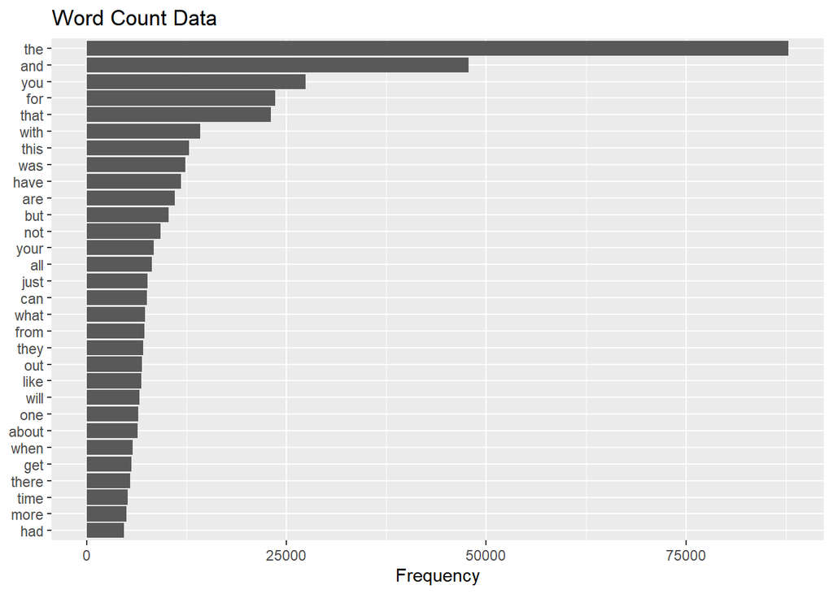

[figure not shown]

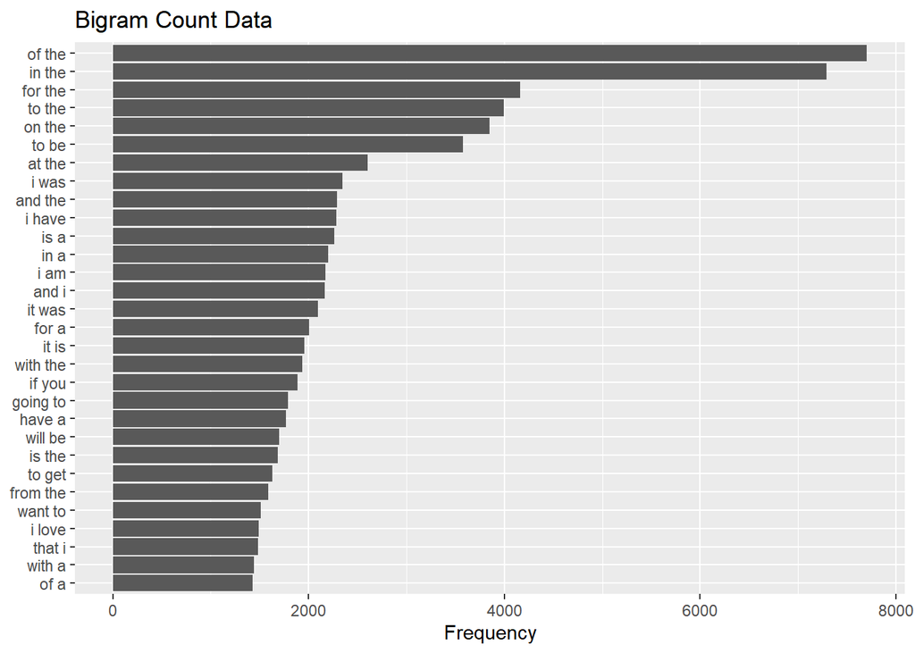

[figure not shown]

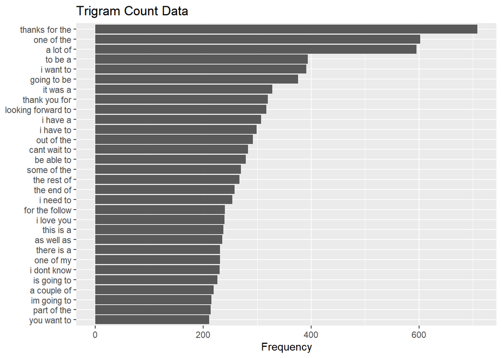

[figure not shown]

[figure not shown]